# Partie 3 : Régression Logistique

- Montrer tout le code
- Cacher tout le code
- Voir les sources

Compléments de Mathématiques 2 – Introduction au Machine Learning

Auteur·rice·s

HAMLIL Mohamed

PARDO TERAN German

EL KORAICHI Mohamed Yassine

ANZID Keltoum

Date de publication

2 mars 2026

# Chargement des données

```r
train_data <- readRDS(here::here("output", "train_data.rds"))
test_data <- readRDS(here::here("output", "test_data.rds"))
cat("Train :", nrow(train_data), "| Test :", nrow(test_data), "\n")
```

```
Train : 21033 | Test : 9013
```

# Régression Logistique

## Principe

**NoteDéfinition**

La régression logistique est un modèle linéaire généralisé qui modélise la probabilité d’appartenance à une classe via la fonction logistique :

$$P(Y = 1 | X) = \frac{1}{1 + e^{-(\beta_0 + \beta_1 X_1 + ... + \beta_p X_p)}}$$

C’est un modèle simple, interprétable et bien adapté à la classification binaire. Nous utilisons ici une régularisation **Elastic Net** (via `glmnet`) qui combine les pénalités L1 (Lasso) et L2 (Ridge) pour éviter le surapprentissage (Zou et Hastie 2005).

## Justification

- **Interprétabilité** : les coefficients indiquent l’effet de chaque variable sur la satisfaction.
- **Robustesse** : la régularisation gère bien les cas où le nombre de variables est élevé.
- **Baseline solide** : c’est un classifieur de référence pour comparer avec des méthodes plus complexes (Hastie, Tibshirani, et Friedman 2009).

## Transformation des variables

- Les variables numériques sont centrées-réduites pour la régularisation.
- La variable `Concentration` est encodée en indicatrices (dummy encoding via la formule `model.matrix`).

## Hyperparamètres

Nous optimisons deux hyperparamètres :

- **alpha** : mélange L1/L2 (0 = Ridge, 1 = Lasso)
- **lambda** : force de la régularisation

Nous utilisons la **validation croisée 5-fold** avec l’**AUC** (aire sous la courbe ROC) comme métrique.

```r
model_file <- here::here("output", "model_logistic.rds")

if (file.exists(model_file)) {
  model_logistic <- readRDS(model_file)
} else {
  ctrl <- trainControl(
    method = "cv",
    number = 5,
    classProbs = TRUE,
    summaryFunction = twoClassSummary,
    savePredictions = "final"
  )

  grid_glmnet <- expand.grid(
    alpha = c(0, 0.25, 0.5, 0.75, 1),
    lambda = 10^seq(-4, -1, length.out = 10)
  )

  set.seed(42)
  model_logistic <- train(
    Satisfaction ~ .,
    data = train_data,
    method = "glmnet",
    trControl = ctrl,
    tuneGrid = grid_glmnet,
    metric = "ROC",
    preProcess = c("center", "scale")
  )
}
```

## Résultats de la validation croisée

```r
cat("Meilleurs hyperparamètres :\n")
```

```
Meilleurs hyperparamètres :
```

```r
cat("  alpha =", model_logistic$bestTune$alpha, "\n")
```

```
  alpha = 0.25
```

```r
cat("  lambda =", model_logistic$bestTune$lambda, "\n")
```

```
  lambda = 0.004641589
```

```r
cat("  AUC (CV) =", round(max(model_logistic$results$ROC), 4), "\n")
```

```
  AUC (CV) = 0.7319
```

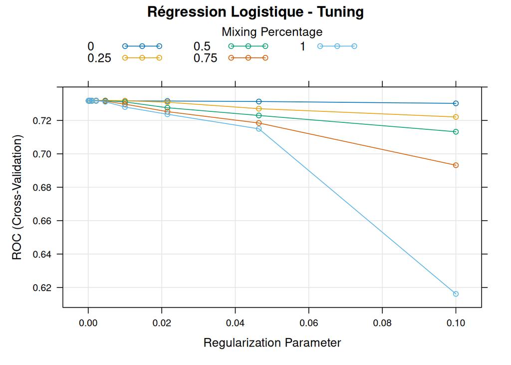

Figure 1: Performance de la régression logistique selon les hyperparamètres

```r
plot(model_logistic, main = "Régression Logistique - Tuning")
```

## Évaluation sur le jeu de test

```r
pred_logistic <- predict(model_logistic, test_data)
prob_logistic <- predict(model_logistic, test_data, type = "prob")

cm_logistic <- confusionMatrix(pred_logistic, test_data$Satisfaction, positive = "Oui")
print(cm_logistic)
```

```
Confusion Matrix and Statistics

          Reference
Prediction  Non  Oui
       Non 2261 1077
       Oui 1853 3822

               Accuracy : 0.6749
                 95% CI : (0.6651, 0.6846)
    No Information Rate : 0.5435
    P-Value [Acc > NIR] : < 2.2e-16

                  Kappa : 0.3348

 Mcnemar's Test P-Value : < 2.2e-16

            Sensitivity : 0.7802
            Specificity : 0.5496
         Pos Pred Value : 0.6735
         Neg Pred Value : 0.6774
             Prevalence : 0.5435
         Detection Rate : 0.4241
   Detection Prevalence : 0.6296
      Balanced Accuracy : 0.6649

       'Positive' Class : Oui
```

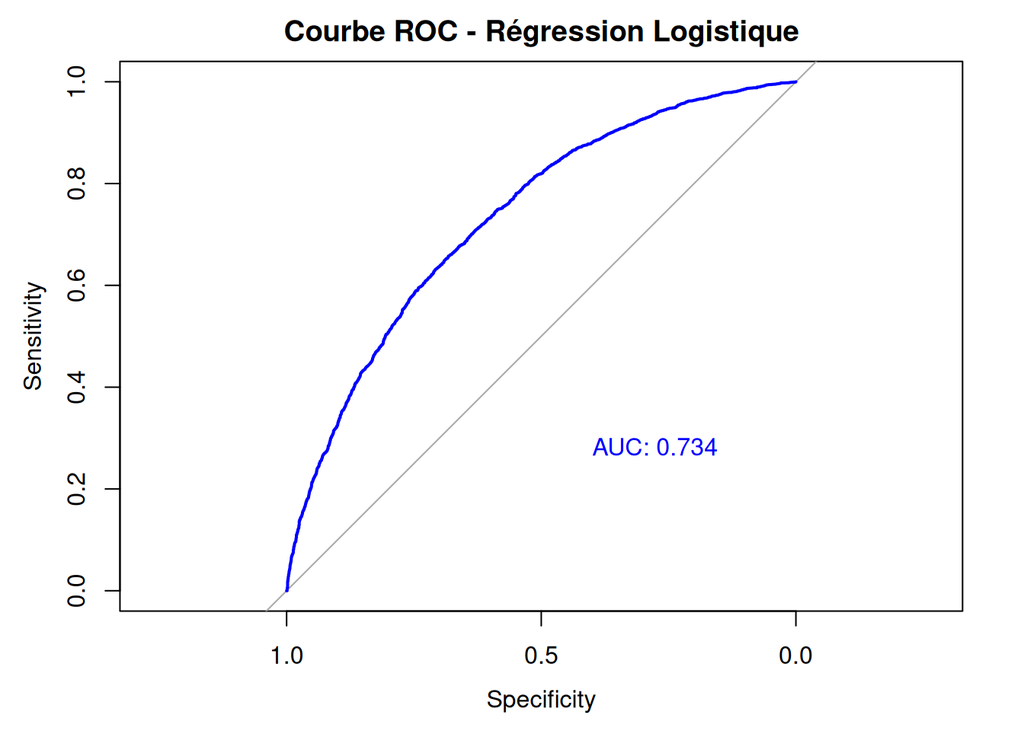

Figure 2: Courbe ROC – Régression Logistique

```r
roc_logistic <- roc(test_data$Satisfaction, prob_logistic$Oui)

plot(roc_logistic, col = "blue", main = "Courbe ROC - Régression Logistique",
     print.auc = TRUE, print.auc.x = 0.4, print.auc.y = 0.3)
```

# Sauvegarde

```r
saveRDS(model_logistic, here::here("output", "model_logistic.rds"))
saveRDS(cm_logistic, here::here("output", "cm_logistic.rds"))
saveRDS(roc_logistic, here::here("output", "roc_logistic.rds"))
cat("Modèle et résultats sauvegardés dans output/\n")
```

```
Modèle et résultats sauvegardés dans output/
```

## Les références

Hastie, Trevor, Robert Tibshirani, et Jerome Friedman. 2009. *The Elements of Statistical Learning*. Springer.

Zou, Hui, et Trevor Hastie. 2005. « Regularization and Variable Selection via the Elastic Net ». *Journal of the Royal Statistical Society: Series B* 67 (2): 301‑20.